# Gopher Rockfish

*Sebastes carnatus*

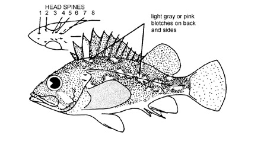

**Body color:** Olive-brown w/ irregular clear, light-gray or pink blotches on back, lateral line, and on lower sides; clear areas tend to run together on lower sides.

**Peritoneum color:** light **Shape between eyes:** concave

**Counts:** D:XIII,12-13, Ar:5-7, P1:16-18, GR:26-30, LLp:35-49, LLs:?-?, V:26

**Occurence:** Northern California - Baja California

**Depth:** 55 meters **Size:** 41 cm **Species code:** 30110

**Similar species:**

- *Black-and-Yellow rockfish* - body black w/ yellow blotches (brown w/ flesh-colored blotches in Gopher RF); gill rakers typically 27-28 (typically 28-30 in Gopher RF)
- *Quillback rockfish* - body w/ broad yellow mottling (irregular, small, and flesh-colored blotches in Gopher RF); spinous dorsal-fin margin deeply incised
- *Brown rockfish* - body w/ darker brown mottling (irregular, small, and flesh-colored blotches in Gopher RF); head spines 6 and 8 typically present

Back to Group

**Corrections:** If you see mistakes or want to suggest changes, please create an [issue](https://github.com/zoyafuso-NOAA/RACE_Survey_App/issues) on the source repository or

*reach out to Liz Dawson (Liz.Dawson AT noaa.gov).*